# Análisis del $R_0$ relacionado con la pobreza: clusters y correlaciones.

DataIntelligence

19-05-2020

### Despliegue del dendrograma de Comunas y $R_0$

Un dendrograma es la representación gráfica en una forma de árbol que resume el proceso de agrupación de un análisis de clusters. Los objetos similares se conectan mediante enlaces cuya posición en el diagrama está determinada por el nivel de similitud/disimilitud entre ellos. El Análisis de Clusters (o Análisis de conglomerados) es una técnica de Análisis Exploratorio de Datos para resolver problemas de clasificación. Su objetivo consiste en ordenar cosas en grupos de forma que el grado de asociación/similitud entre miembros del mismo cluster sea más fuerte que el grado de asociación/similitud entre miembros de diferentes clusters. Cada cluster se describe como la clase a la que sus miembros pertenecen. El análisis de clusters es un método que permite descubrir asociaciones y estructuras en los datos que no son evidentes a priori pero que pueden ser útiles una vez que se han encontrado. Los resultados de un Análisis de Clusters pueden contribuir a la definición formal de un esquema de clasificación, tal como una taxonomía para un conjunto de objetos, sugerir modelos estadísticos para describir poblaciones o asignar nuevos individuos a las clases para diagnóstico e identificación, por ejemplo.

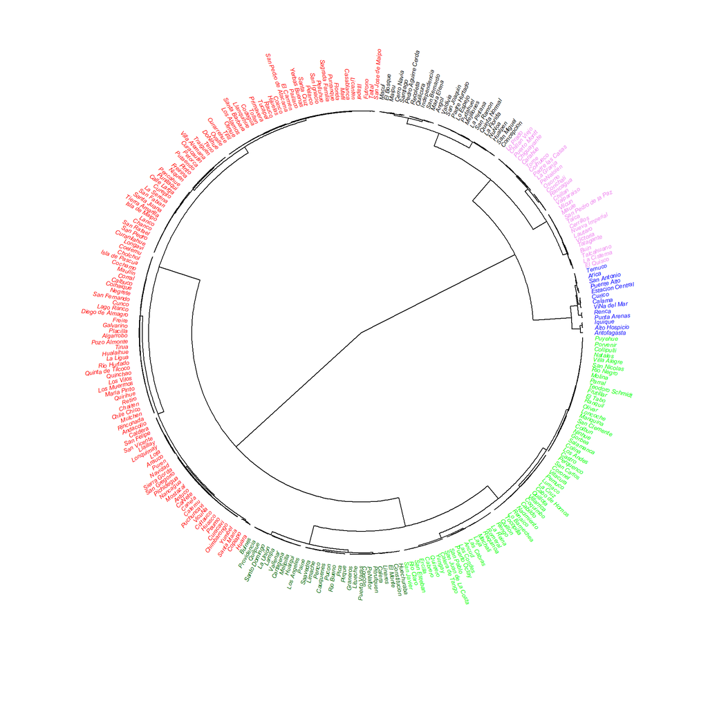

### Despliegue del dendrograma de Comunas, $R_0$ y porcentaje de pobreza comunal.

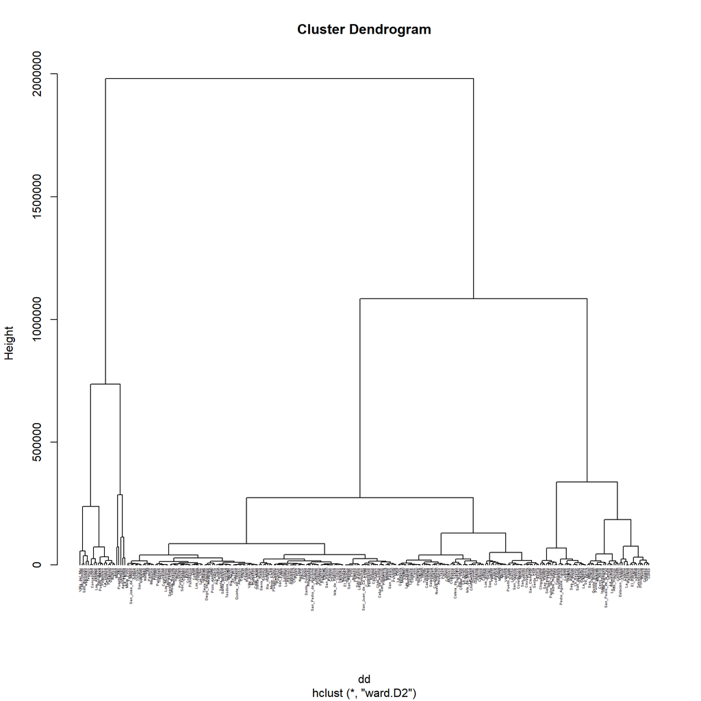

### Zoom al dendrograma anterior.

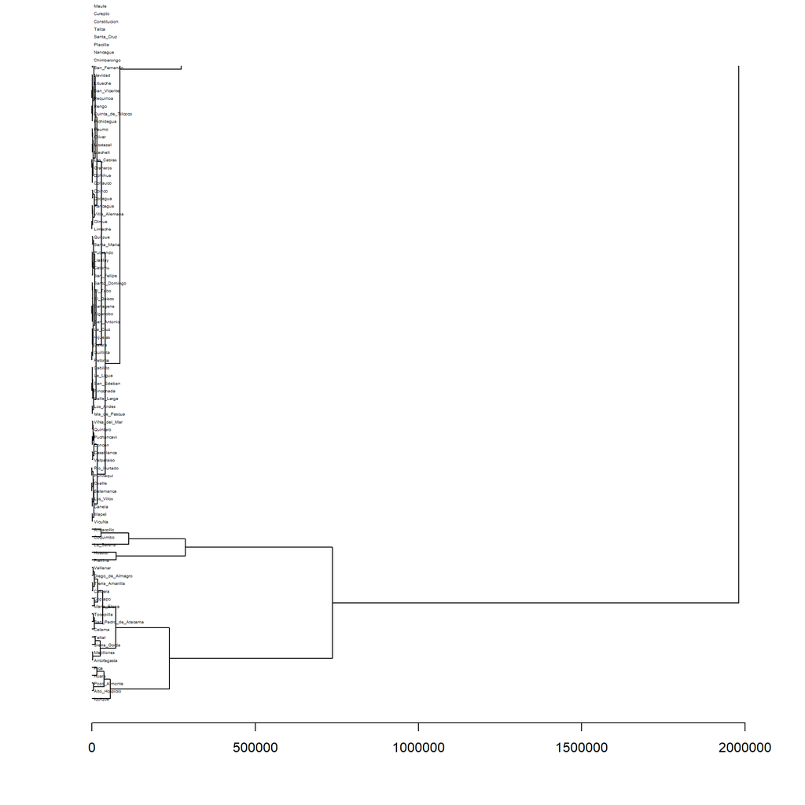

### Despliegue del dendrograma circular de Comunas, $R_0$ y porcentaje de pobreza comunal.

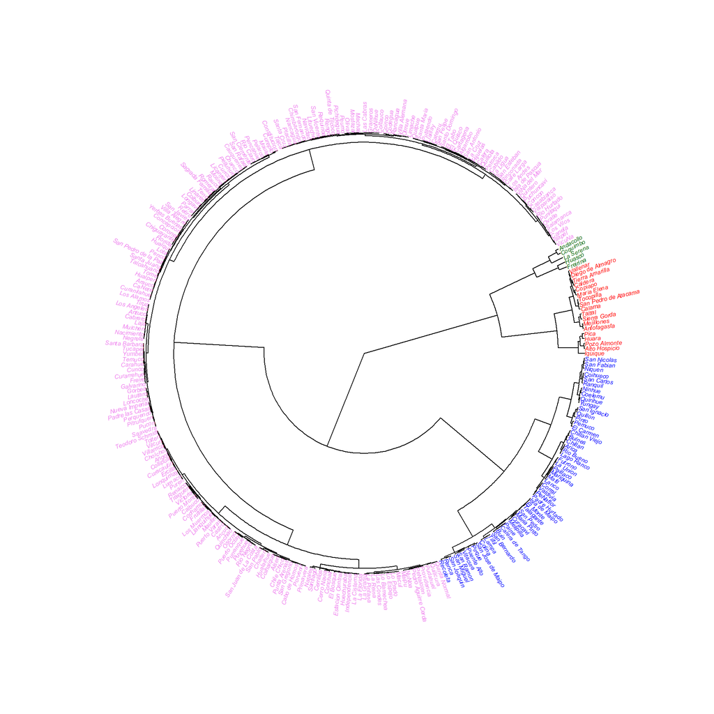

### Correlacion de Pearson entre $R_0$ y pobreza:

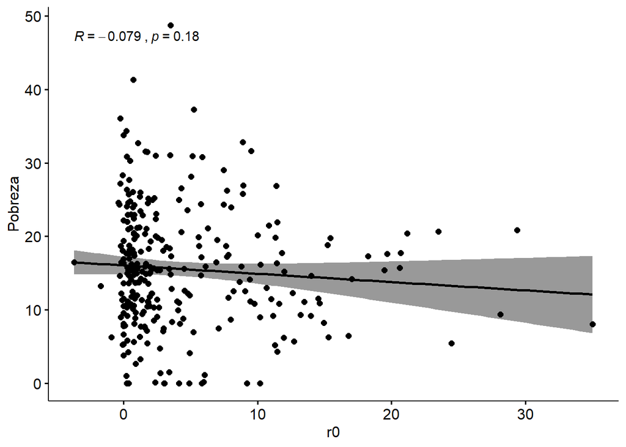

```
##
##  Pearson's product-moment correlation
##
## data:  covid19_sin_title_com$r0 and covid19_sin_title_com$Pobreza
## t = -1.3291, df = 278, p-value = 0.1849
## alternative hypothesis: true correlation is not equal to 0
## 95 percent confidence interval:
##  -0.1948680  0.0381148
## sample estimates:
##         cor
## -0.07946167
```

#### Normalización

##### La normalización implica ajustar los valores medidos en diferentes escalas respecto a una común, a menudo previo a un proceso de realizar promedios. En R se pueden escalar las variables de una base de datos por medio de la función scale:

covid19.normalizado<- scale(covid19[,c(2,3)],center=T,scale=T)

### Datos normalizados.

| r0 | Pobreza |
| --- | --- |
| 4.1225237 | -0.7557837 |
| 4.3446187 | 0.6418068 |
| -0.7217958 | -0.5916454 |
| -0.9154899 | -1.1286113 |
| 0.0996566 | -0.4363992 |
| 5.3192850 | -0.9139991 |
| 1.3219016 | -1.1362448 |
| -0.7565067 | -1.4305588 |
| -0.6023414 | -1.5653816 |
| 2.1583500 | -1.1043232 |